# FIT3152asm_1_final_markdown

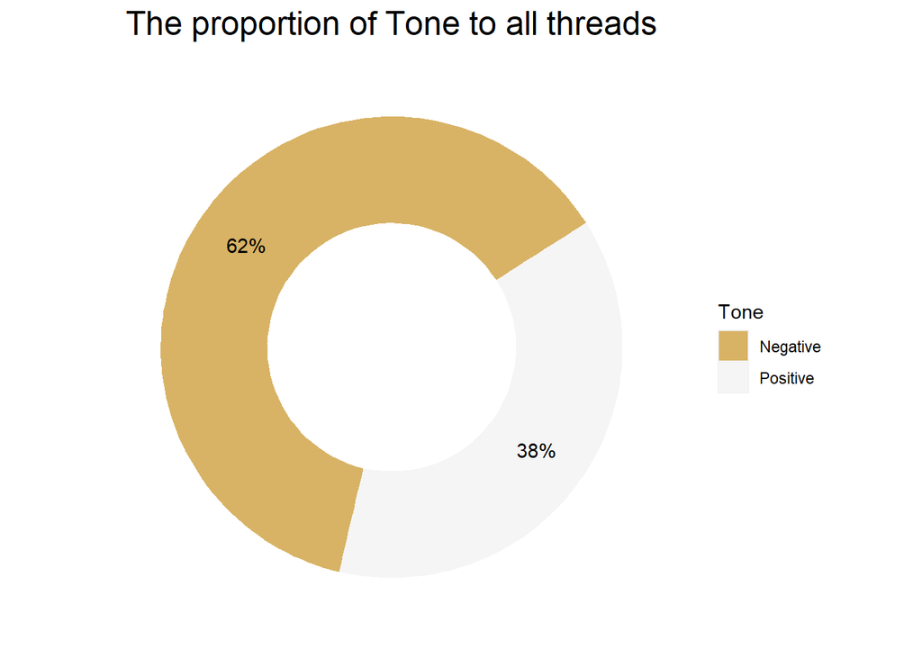

```r
df_2 <- data_tidy %>%
  group_by(ThreadID) %>%
  summarise(Tone = median(Tone, na.rm = TRUE))
df_2 = df_2 %>% mutate(Tone = ifelse(Tone >50 , "Positive", "Negative"))%>%
  group_by(Tone) %>% summarise(count =n())

df_for_donut_chart <- df_2


# Compute percentages
df_for_donut_chart$fraction <- df_for_donut_chart$count / sum(df_for_donut_chart$count)

ggplot(df_for_donut_chart, aes(x=2,y=fraction,fill=Tone)) +
geom_col()+
    coord_polar(theta="y",start = 1) +
  geom_text(aes(label= paste0(round(fraction*100),"%")), position = position_stack(vjust = .5))+
  theme(panel.background = element_blank(),
        axis.line = element_blank(),
        axis.text = element_blank(),
        axis.ticks = element_blank(),
        axis.title = element_blank(),
        plot.title = element_text(hjust = .5,size = 18)
        )+labs(title = "The proportion of Tone to all threads") +
  scale_fill_brewer(palette="BrBG") +xlim(0.5,2.5)
```

1. Sentiments : are most the thread +ve ? 2. Pronoun : What are the most used pronoun? 3. Structure : What are the mean of WC and WPS?

```
b By analysing the linguistic variables for all or some of the threads, is it possible to see a
difference in the language used by different groups?
--------------------------------------------------------------------------------------------

Find out the languages used between the most postivie and negative threads.
    1. find out the 10 most active threads
```

```r
data_tidy_norm <- data_tidy_norm %>% cbind(ThreadID = data$ThreadID)
df_active_10 <-  data_tidy %>% group_by(ThreadID)%>% summarise(count = n()) %>% arrange(desc(count))
df_active_10 <- head(df_active_10,10)
df_active_10
```

```
## # A tibble: 10 x 2
##    ThreadID count
##       <int> <int>
##  1   283958   136
##  2   252620   127
##  3   127115   114
##  4   472752   109
##  5   145223    95
##  6   532649    79
##  7   309286    71
##  8   191868    69
##  9   296985    65
## 10   249001    56
```

```r
df <-  data_tidy1 %>% filter(data$ThreadID %in% df_active_10$ThreadID  ) %>% arrange(ThreadID)
```

```
  2. In the most active threads, find out the most most postivie and negative threads. The data set is called data_nega_pose
```

```r
data_nega_pose <-  df %>% group_by(ThreadID) %>% summarise(mean = mean(Tone))
data_nega_pose1 <- data_nega_pose
data_nega_pose = data_nega_pose %>% mutate(emo = ifelse(mean >50 , "Positive", "Negative"))%>%
  group_by(emo) %>% arrange(desc(mean))


#It is noticed that Thread 472752 is the most Positive and 309286 is the most Negative
#most positve
data.mostPose <- data_tidy %>% filter(ThreadID =="472752" )
data.mostPose <- data.mostPose[5:19]
data.mostPose1 <- data.mostPose

#most negative
data.mostNega <- data_tidy %>% filter(ThreadID =="309286" )
data.mostNega <- data.mostNega[5:19]
data.mostNega1 <- data.mostNega
```

Based on the data collected from the most negative and positive, we can make a Radarchart to visualise the difference

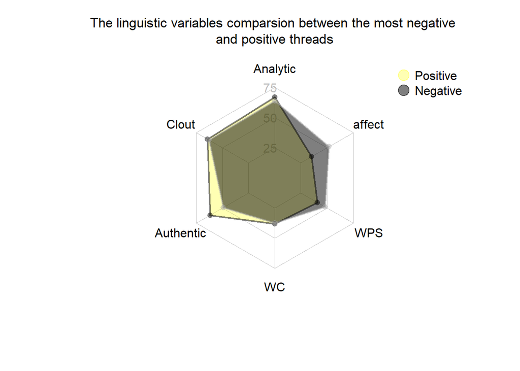

```r
library(fmsb)
data.mostPose <- data.mostPose %>% select(Analytic,Clout,Authentic,WC,WPS,affect)


data.mostPose <- as.data.frame(lapply(data.mostPose[,], min_max_normalisation))
data.mostPose <- data.mostPose %>% summarise(Analytic_m = mean(Analytic)*100,
                                             Clout_m = mean(Clout)*100,
                                             Authentic_m = mean(Authentic)*100,
                                            WC_m = mean(WC)*100,
                                            WPS_m = mean(WPS)*100,
                                            affect_m = mean(affect)*100
                                             )

# negative
data.mostNega <- data.mostNega %>% select(Analytic,Clout,Authentic,WC,WPS,affect)


data.mostNega <- as.data.frame(lapply(data.mostNega[,], min_max_normalisation))
data.mostNega <- data.mostNega %>% summarise(Analytic_m = mean(Analytic)*100,
                                             Clout_m = mean(Clout)*100,
                                             Authentic_m = mean(Authentic)*100,
                                            WC_m = mean(WC)*100,
                                            WPS_m = mean(WPS)*100,
                                            affect_m = mean(affect)*100
                                             )

radar_data_Pose <- data.mostNega %>% rbind(data.mostPose )



radar_data_Pose <-data.frame( Analytic = c(75, 0 , data.mostPose[1,1],data.mostNega[1,1] ),
                              Clout = c(75, 0 , data.mostPose[1,2],data.mostNega[1,2]  ),
                              Authentic = c(75, 0 , data.mostPose[1,3],data.mostNega[1,3]  ),
                              WC = c(75, 0 , data.mostPose[1,4],data.mostNega[1,4]  ),
                              WPS = c(75, 0 , data.mostPose[1,5],data.mostNega[1,5]  ),
                              affect = c(75, 0 , data.mostPose[1,6],data.mostNega[1,6]  ),
                              row.names = c("max","min","Positive","Negative")
                              )
#defien the colors filled
colors_fill <- c(scales::alpha("yellow", 0.3),scales::alpha("black", 0.5))
#define the line colors
colors_line <- c(scales::alpha("black", 0.5),scales::alpha("darkgrey", 0.5))

 radarchart(radar_data_Pose, axistype = 1,
           seg = 2,
    # Customize the polygon
     pfcol =colors_fill, plwd = 2, plty = 1,
    # Customize the grid
    cglcol = "grey", cglty = 1, cglwd = 0.8,
    pcol = colors_line,
    # Customize the axis
    axislabcol = "grey",
    caxislabels = c(25, 50, 75),
    palcex = 1.5)

  title(main = "The linguistic variables comparsion between the most negative \nand positive threads",
      cex.main = 1.1,
      font.main= 1,
      cex.sub = 0.75, font.sub = 1, col.sub = "green",
      col.lab ="darkblue")


legend( x=1.3,y=1.3,legend = row.names( radar_data_Pose[3:4,] ) ,
        bty = "n",
        pch = 20,
        col=colors_fill,
        cex=1,
        pt.cex=3)
```

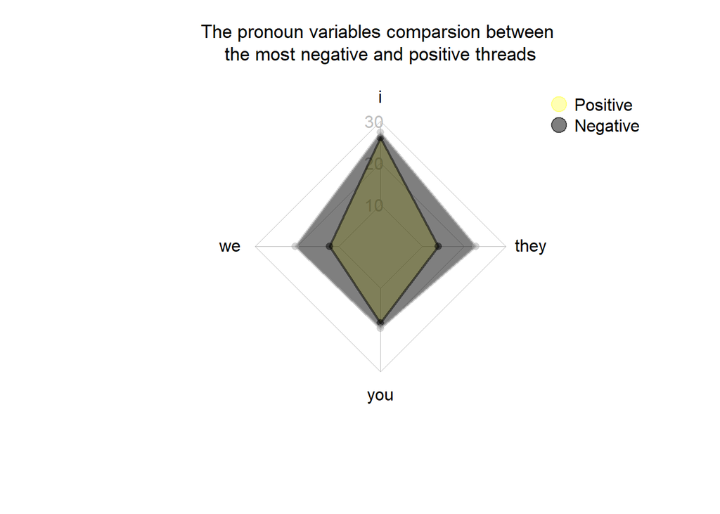

```r
library(fmsb)
data.mostPose1 <- data.mostPose1 %>% select(i ,we,they, you)
data.mostPose1 <- as.data.frame(lapply(data.mostPose1[,], min_max_normalisation))
data.mostPose1 <- data.mostPose1 %>% summarise(i_m = mean(i)*100,
                                             we_m = mean(we)*100,
                                             you_m = mean(you)*100,
                                            they_m = mean(they)*100
                                             )

# negative
data.mostNega1 <- data.mostNega1 %>% select(i ,we,they, you)
data.mostNega1 <- as.data.frame(lapply(data.mostNega1[,], min_max_normalisation))
data.mostNega1 <- data.mostNega1 %>% summarise(i_m = mean(i)*100,
                                             we_m = mean(we)*100,
                                             you_m = mean(you)*100,
                                            they_m = mean(they)*100
                                             )


radar_data_Pose <- data.mostNega1 %>% rbind(data.mostPose1 )
radar_data_Pose <-data.frame( i = c(30, 0 , data.mostPose1[1,1],data.mostNega1[1,1] ),
                              we = c(30, 0 , data.mostPose1[1,2],data.mostNega1[1,2]  ),
                              you = c(30, 0 , data.mostPose1[1,3],data.mostNega1[1,3]  ),
                              they= c(30, 0 , data.mostPose1[1,4],data.mostNega1[1,4]  ),
                              row.names = c("max","min","Positive","Negative")
                              )

 radarchart(radar_data_Pose, axistype = 1,
           seg = 2,
    # Customize the polygon
     pfcol =colors_fill, plwd = 2, plty = 1,
    # Customize the grid
    cglcol = "grey", cglty = 1, cglwd = 0.8,
    pcol = colors_line,
    # Customize the axis
    axislabcol = "grey",
    caxislabels = c(10, 20, 30))

  title(main = "The pronoun variables comparsion between \nthe most negative and positive threads",
      cex.main = 1.1,
        font.main= 1,
      cex.sub = 0.75, font.sub = 1, col.sub = "green",
      col.lab ="darkblue")


legend( x=1.3,y=1.3,legend = row.names( radar_data_Pose[3:4,] ) ,
        bty = "n",
        pch = 20,
        col=colors_fill,
        cex=1,
        pt.cex=3)
```

What about the pronoun they use?

```
c Does the language used within threads (or between threads) change over time? How
    consistent or variable is the language used within threads?
--------------------------------------------------------------------------------------------
```

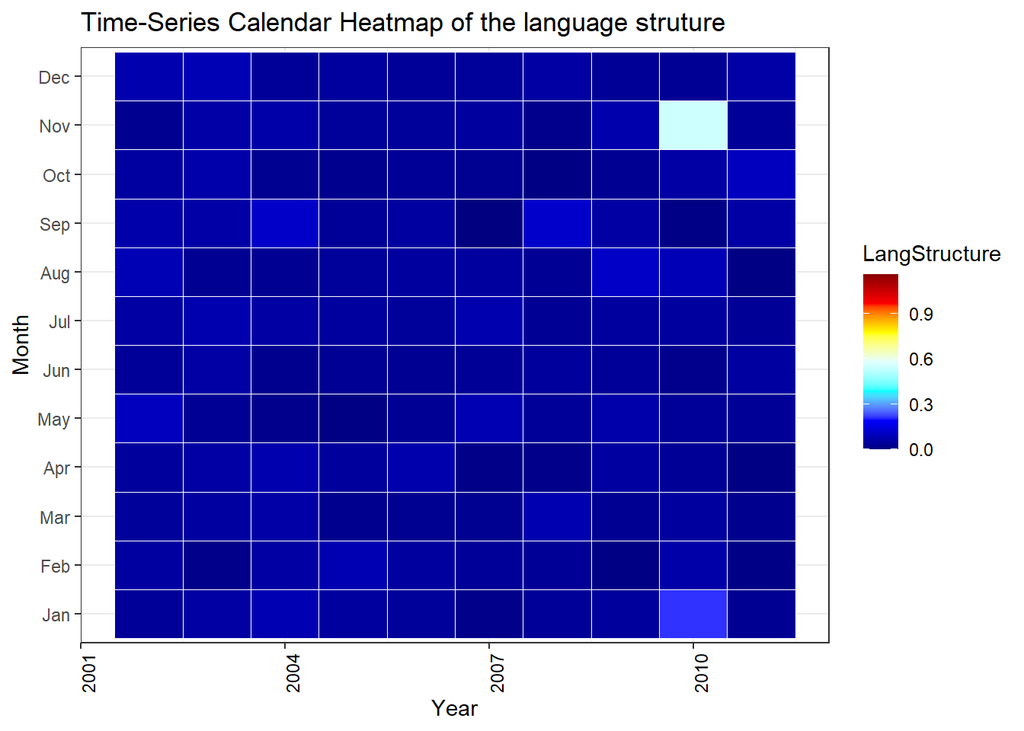

```r
data_tidy_norm <-  normalise_data_tidy(data_tidy1)
data_tidy_norm <- data_tidy_norm %>% cbind(ThreadID = data_tidy1$ThreadID, Date =data_tidy1$Date )


data_tidy_norm <- data_tidy_norm %>% select(Analytic,Clout,Tone,Authentic,WC,WPS,affect,ThreadID,Date, i ,we,they, you )%>%
  mutate(LangStructure = data_tidy_norm[,1] + data_tidy_norm[,6] )

grp_yr = data.frame(data_tidy_norm ) %>% cbind(year = data_tidy1$year, month=data_tidy1$month )

grp_yr <- grp_yr %>% group_by(ThreadID,year,month) %>% summarise(count =n(),LangStructure = mean(LangStructure,na.rm = TRUE),)%>%
  arrange(desc(year))

# visualise it
mycol <- c("navy", "blue", "cyan", "lightcyan", "yellow", "red", "red4")
ggplot(grp_yr, aes(x= year , y=month, color =LangStructure )) +
  geom_tile (aes(fill=LangStructure),colour = "white" )+labs(
    title = "Time-Series Calendar Heatmap of the language struture",
       x = "Year",
       y = "Month"
    )+
  scale_fill_gradientn(colours = mycol)+theme_bw()+
  theme(axis.text.x = element_text(, color="BLACK", angle=90))
```

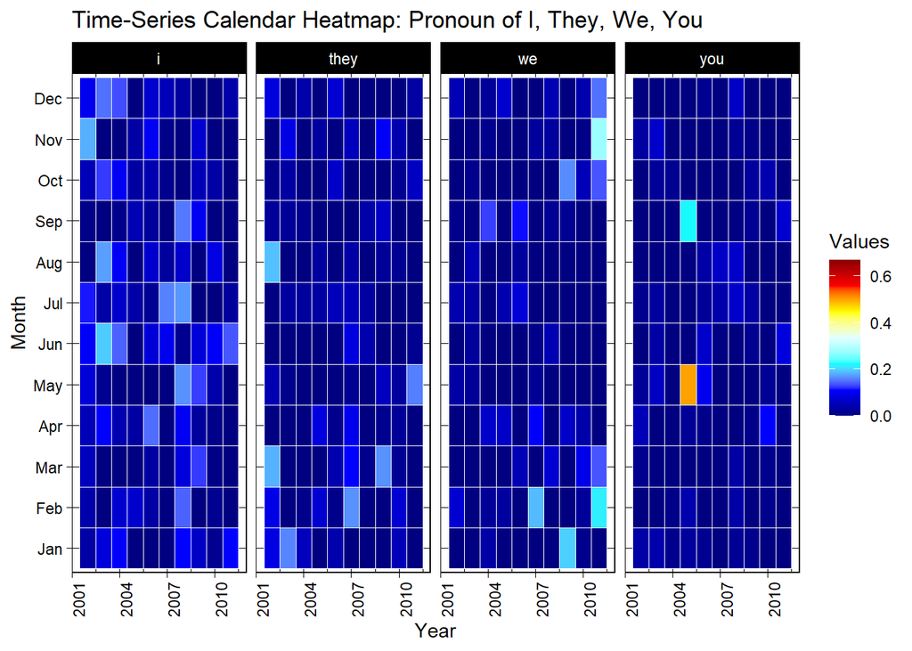

```r
data_tidy_norm <- data_tidy_norm %>% select(ThreadID,Date, i ,we,they, you )


grp_yr <- data.frame(data_tidy_norm ) %>% cbind(year = data_tidy1$year, month=data_tidy1$month )

grp_yr <- grp_yr %>% group_by(ThreadID,year,month) %>% summarise(count =n(),i=median(i),
            we=median(we),
            you=median(you),
            they = median(they))%>%
  arrange(desc(year))

grp_yr <-grp_yr %>%   pivot_longer(cols = c(`i`,`we`,`you`,`they`), names_to = "Pronoun", values_to= "Values")

mycol <- c("navy", "blue", "cyan", "lightcyan", "yellow", "red", "red4")
ggplot(grp_yr, aes(x= year , y=month, color = Values)) +
  geom_tile (aes(fill=Values),colour = "white" ) +
  scale_fill_gradientn(colours = mycol)+facet_grid(~Pronoun)+theme_linedraw()+
  theme(axis.text.x = element_text(, color="BLACK", angle=90))+labs(
    title = "Time-Series Calendar Heatmap: Pronoun of I, They, We, You",
       x = "Year",
       y = "Month"
    )
```

==============================================================================================================  
Q3 Challenge: Social networks online=

```r
#filter data for social network analysis
filter_dt <- function(yr,month1){
df <-  data_tidy1 %>% filter(year == yr, month == month1)
df <- df %>% select(ThreadID, AuthorID)
df <- inner_join(df, df, by = "ThreadID")
df3 <- apply(df, 2, as.character) #AuthorID as character will become vertex ID
df3 <- as.tibble(df3)
df3 <- df3 %>% rename(sources = AuthorID.x, destinations= AuthorID.y)
df3 <- df3 %>% filter(sources != destinations)
# df3 <- df3 %>% distinct()
return(df3)
}
```

2002 feb

```r
library(igraph)
#set a class of table so that I can return multiple
#objects for the function of tabulate_dt
setClass(Class = "Table",representation (edges ="list",
                                         nodes ="list"))

tabulate_dt <-  function(df3){

sources <- df3  %>%
  distinct(sources) %>%
  rename(label = sources)

## take destinication from letters and make it as "destinations" and renamed as "label"
destinations <- df3 %>%
  distinct(destinations) %>%
  rename(label = destinations)


##To create a single dataframe with a column with the unique locations
nodes <- full_join(sources, destinations, by = "label")
nodes <- nodes %>% rowid_to_column("id")

per_route <- df3 %>%
  group_by(sources, destinations) %>%
  summarise(weight = n()) %>%
  ungroup()


edges <- per_route %>%
  left_join(nodes, by = c("sources" = "label")) %>%
  rename(from = id)

edges <- edges %>%
  left_join(nodes, by = c("destinations" = "label")) %>%
  rename(to = id)

edges <- select (edges, from, to, weight)

#this will return an instance of this class -- Table
return(new("Table",edges=edges,nodes=nodes))
}
```

create function for centrality summary of node within the network

```r
network_centrality <- function(routes_igraph){
degree_table <-  as.table( degree(routes_igraph))
betweenness_table <-  as.table( betweenness(routes_igraph))
closeness_table <-  as.table( closeness(routes_igraph))
eigenvector_table <-  as.table(     evcent(routes_igraph)$vector)

#merge table
bt_degree <- merge(degree_table, betweenness_table,by= "Var1" )
bt_degree <-  bt_degree %>% rename(Betweenness = Freq.x, Degree=Freq.y , id=Var1)

cls_eig <- merge(closeness_table,eigenvector_table, by= "Var1" )
cls_eig <-  cls_eig %>% rename(Closeness = Freq.x, Eigenvector=Freq.y,id=Var1)

network_summary <-  merge(bt_degree,cls_eig,by= "id")
network_summary <-  merge(nodes,network_summary,by="id") %>% select(-id)

#round all numbers in 2 digits
network_summary <- network_summary %>%
               mutate(Degree = round(Degree,2),
                      Closeness =round( Closeness,2),
                      Eigenvector = round(Eigenvector,2))

network_summary <-  network_summary %>% arrange(desc(Betweenness,Degree,Eigenvector,Closeness) )
return(network_summary)
}
```

network for 2002 feb

```r
df3 <- filter_dt(2002,"Feb")
```

```r
feb_table <- tabulate_dt(df3)
# access your information of feb_table and make them as dataframe
edges <- as.data.frame(feb_table@edges)
nodes <- as.data.frame(feb_table@nodes)

routes_igraph <- graph_from_data_frame(d = edges,  vertices=nodes, directed = F)

network_centrality(routes_igraph)
```

```
##    label Betweenness Degree Closeness Eigenvector
## 1   1038          20  49.50      0.01        1.00
## 2     27          10   1.50      0.01        0.67
## 3   4876          10   0.50      0.01        0.72
## 4   4574           8   0.00      0.01        0.54
## 5    118           8  11.50      0.01        0.33
## 6   4919           8   1.07      0.01        0.46
## 7   3785           6  16.40      0.01        0.28
## 8   5697           4   0.00      0.01        0.31
## 9   1740           4  11.00      0.01        0.24
## 10   986           4  12.00      0.01        0.16
## 11   931           2   0.00      0.00        0.00
## 12   186           2   0.00      0.01        0.12
## 13    51           2   0.00      0.01        0.03
## 14   444           2   0.00      0.00        0.00
## 15  5103           2   0.00      0.00        0.00
## 16  3610           2   0.00      0.01        0.04
## 17  1390           2   0.00      0.00        0.00
```

```r
#count the vertexes and nodes
vcount(routes_igraph)
```

```
## [1] 17
```

```r
ecount(routes_igraph)
```

```
## [1] 48
```

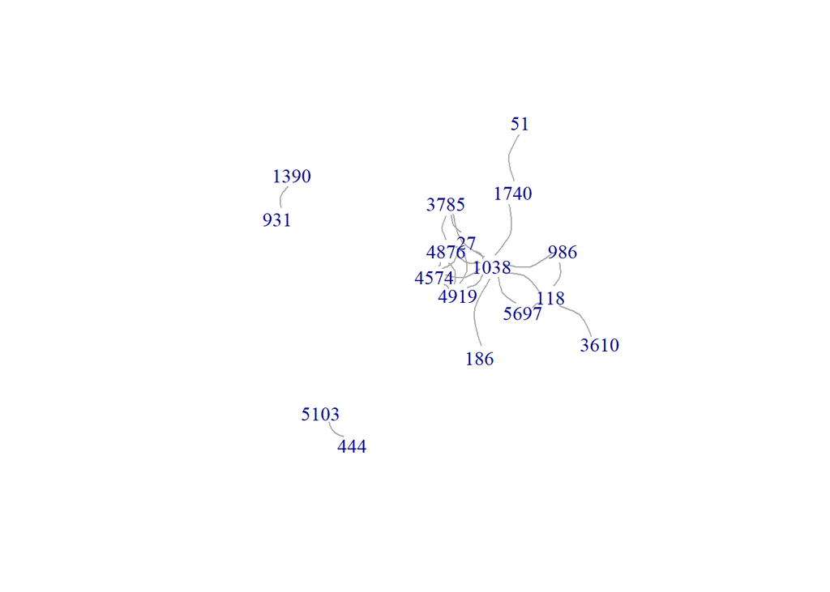

```r
plot(routes_igraph,
     vertex.shape="none",
     edge.curved=TRUE)
```

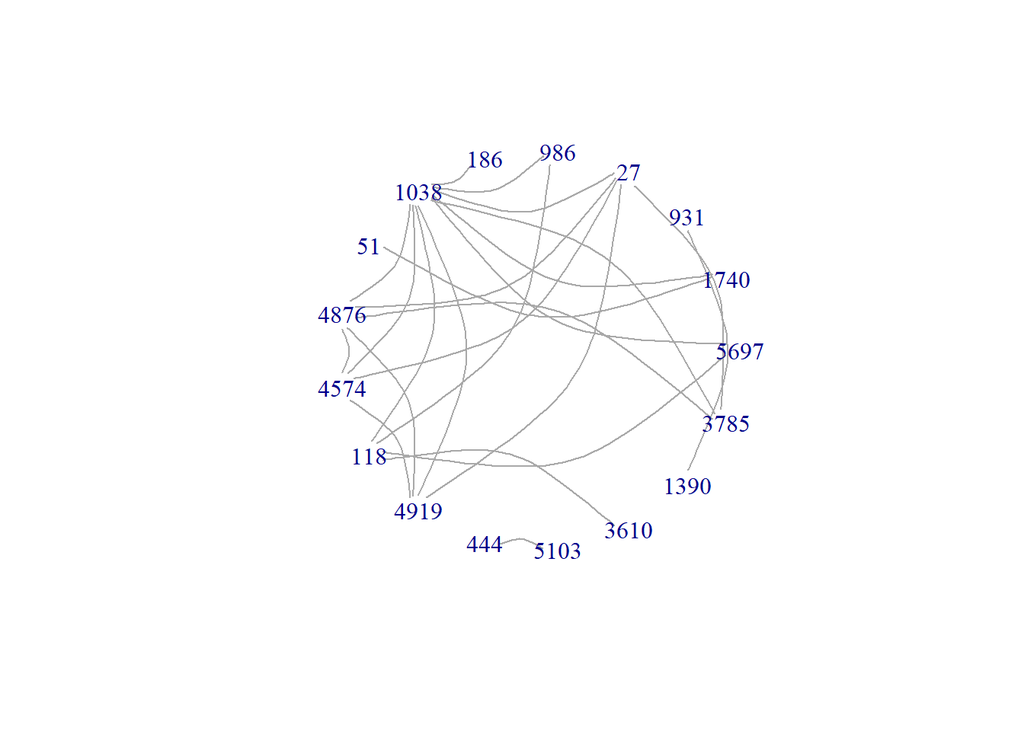

```r
plot(routes_igraph, layout = layout_in_circle(routes_igraph),
     vertex.shape="none",
     edge.curved=TRUE)
```

```r
# change the degree size
# plot(routes_igraph, layout = layout_with_graphopt,
#      edge.arrow.size = 0.2,
#      vertex.size=deg*3,
#      vertex.color=rgb(0.1,0.7,0.8,0.5) )
```

network for 2002 march

```r
df3 <- filter_dt(2002,"Mar")
mar_table <- tabulate_dt(df3)
# access your information of feb_table and make them as dataframe
edges <- as.data.frame(mar_table@edges)
nodes <- as.data.frame(mar_table@nodes)

routes_igraph <- graph_from_data_frame(d = edges, vertices = nodes, directed = F)
network_centrality(routes_igraph)
```

```
##    label Betweenness Degree Closeness Eigenvector
## 1    118          28  83.64      0.01        0.99
## 2   5697          26  81.04      0.01        1.00
## 3   1740          18   2.51      0.01        0.88
## 4    111          12  20.00      0.01        0.71
## 5    113          12   4.00      0.01        0.29
## 6   6025          12   4.00      0.01        0.29
## 7   4251          12   4.00      0.01        0.29
## 8   4298          12   4.00      0.01        0.29
## 9   2508          10  46.66      0.01        0.40
## 10   194          10   0.00      0.01        0.70
## 11   986           8  13.00      0.01        0.12
## 12  6207           8  20.00      0.01        0.12
## 13  1038           6  24.00      0.01        0.02
## 14  6085           6  26.00      0.01        0.15
## 15   887           6   0.00      0.01        0.19
## 16  1162           6   0.00      0.01        0.12
## 17  3610           4   4.00      0.01        0.10
## 18  4291           4  19.40      0.01        0.06
## 19    42           2   0.00      0.01        0.00
## 20  5720           2   0.00      0.01        0.01
## 21  4284           2   0.00      0.01        0.05
## 22    27           2   0.00      0.00        0.00
## 23  2748           2   0.00      0.01        0.04
## 24  1946           2   0.00      0.00        0.00
```

```r
#count the vertexes and nodes
vcount(routes_igraph)
```

```
## [1] 24
```

```r
ecount(routes_igraph)
```

```
## [1] 106
```

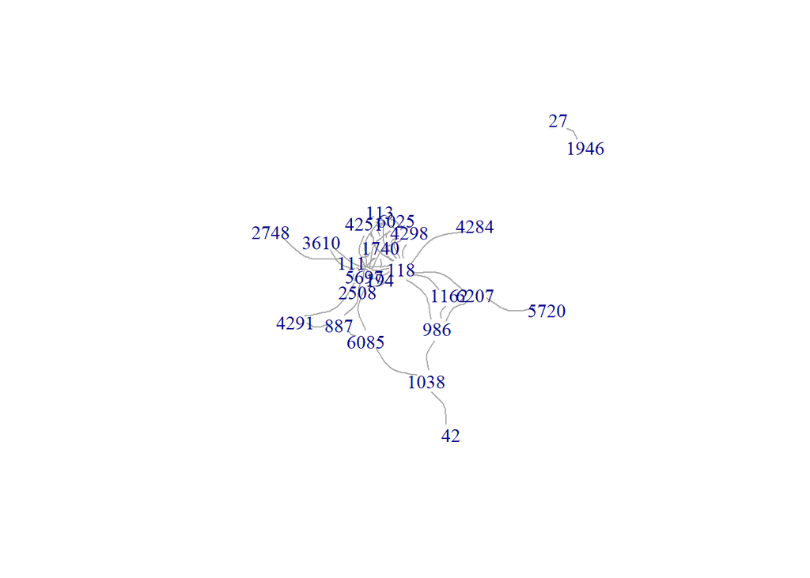

```r
plot(routes_igraph,
     vertex.shape="none",
     edge.curved=TRUE)
```

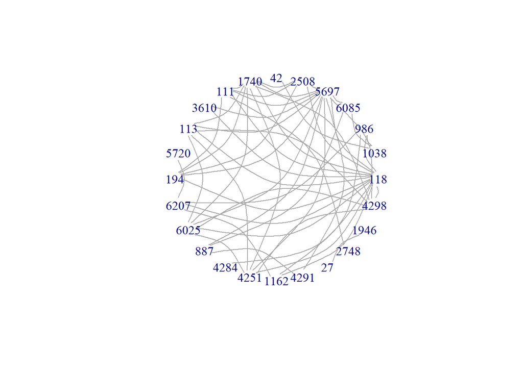

```r
plot(routes_igraph, layout = layout_in_circle(routes_igraph),
     vertex.shape="none",
     edge.curved=TRUE)
```

```r
# change the degree size
# plot(routes_igraph, layout = layout_with_graphopt,
#      edge.arrow.size = 0.2,
#      vertex.size=deg*3,
#      vertex.color=rgb(0.1,0.7,0.8,0.5) )
```